# Data 621 - HW3

Devin Teran, Atina Karim, Tom Hill, Amit Kapoor

4/18/2021

# Introduction

In this homework assignment, you will explore, analyze and model a data set containing information on crime for various neighborhoods of a major city. Each record has a response variable indicating whether or not the crime rate is above the median crime rate (1) or not (0). Your objective is to build a binary logistic regression model on the training data set to predict whether the neighborhood will be at risk for high crime levels. You will provide classifications and probabilities for the evaluation data set using your binary logistic regression model.

# Data Exploration

```
##   zn indus chas   nox    rm   age    dis rad tax ptratio lstat medv target
## 1  0 19.58    0 0.605 7.929  96.2 2.0459   5 403    14.7  3.70 50.0      1
## 2  0 19.58    1 0.871 5.403 100.0 1.3216   5 403    14.7 26.82 13.4      1
## 3  0 18.10    0 0.740 6.485 100.0 1.9784  24 666    20.2 18.85 15.4      1
## 4 30  4.93    0 0.428 6.393   7.8 7.0355   6 300    16.6  5.19 23.7      0
## 5  0  2.46    0 0.488 7.155  92.2 2.7006   3 193    17.8  4.82 37.9      0
## 6  0  8.56    0 0.520 6.781  71.3 2.8561   5 384    20.9  7.67 26.5      0
```

```
## [1] 466  13
```

Our dataset has 466 records. Explanation of features:

- znn: proportion of residential land zoned for large lots (over 25000 square feet) (predictor variable)
- indus: proportion of non-retail business acres per suburb (predictor variable)
- chas: a dummy var. for whether the suburb borders the Charles River (1) or not (0) (predictor variable)
- nox: nitrogen oxides concentration (parts per 10 million) (predictor variable)
- rm: average number of rooms per dwelling (predictor variable)
- age: proportion of owner-occupied units built prior to 1940 (predictor variable)
- dis: weighted mean of distances to five Boston employment centers (predictor variable)
- rad: index of accessibility to radial highways (predictor variable)
- tax: full-value property-tax rate per $10,000 (predictor variable)
- ptratio: pupil-teacher ratio by town (predictor variable)
- lstat: lower status of the population (percent) (predictor variable)
- medv: median value of owner-occupied homes in $1000s (predictor variable)
- target: whether the crime rate is above the median crime rate (1) or not (0) (response variable)

This also appears to be a public dataset available through Carnegie Mellon University http://lib.stat.cmu.edu/datasets/boston. The original white paper was a 1978 study published in the *Journal of Environmental Economics and Management*, which was interested in the marginal price consumers would pay for improved air quality. The communities studied were in the greater Boston area.

```
##        zn             indus             chas              nox
##  Min.   :  0.00   Min.   : 0.460   Min.   :0.00000   Min.   :0.3890
##  1st Qu.:  0.00   1st Qu.: 5.145   1st Qu.:0.00000   1st Qu.:0.4480
##  Median :  0.00   Median : 9.690   Median :0.00000   Median :0.5380
##  Mean   : 11.58   Mean   :11.105   Mean   :0.07082   Mean   :0.5543
##  3rd Qu.: 16.25   3rd Qu.:18.100   3rd Qu.:0.00000   3rd Qu.:0.6240
##  Max.   :100.00   Max.   :27.740   Max.   :1.00000   Max.   :0.8710
##        rm             age              dis              rad
##  Min.   :3.863   Min.   :  2.90   Min.   : 1.130   Min.   : 1.00
##  1st Qu.:5.887   1st Qu.: 43.88   1st Qu.: 2.101   1st Qu.: 4.00
##  Median :6.210   Median : 77.15   Median : 3.191   Median : 5.00
##  Mean   :6.291   Mean   : 68.37   Mean   : 3.796   Mean   : 9.53
##  3rd Qu.:6.630   3rd Qu.: 94.10   3rd Qu.: 5.215   3rd Qu.:24.00
##  Max.   :8.780   Max.   :100.00   Max.   :12.127   Max.   :24.00
##       tax           ptratio         lstat             medv
##  Min.   :187.0   Min.   :12.6   Min.   : 1.730   Min.   : 5.00
##  1st Qu.:281.0   1st Qu.:16.9   1st Qu.: 7.043   1st Qu.:17.02
##  Median :334.5   Median :18.9   Median :11.350   Median :21.20
##  Mean   :409.5   Mean   :18.4   Mean   :12.631   Mean   :22.59
##  3rd Qu.:666.0   3rd Qu.:20.2   3rd Qu.:16.930   3rd Qu.:25.00
##  Max.   :711.0   Max.   :22.0   Max.   :37.970   Max.   :50.00
##      target
##  Min.   :0.0000
##  1st Qu.:0.0000
##  Median :0.0000
##  Mean   :0.4914
##  3rd Qu.:1.0000
##  Max.   :1.0000
```

Looking at summary statistics, there are several proportions, like znn, indus, age, and lstat. There is also a dummy variable, chas, for whether the community borders the Charles River. There are also no missing values.

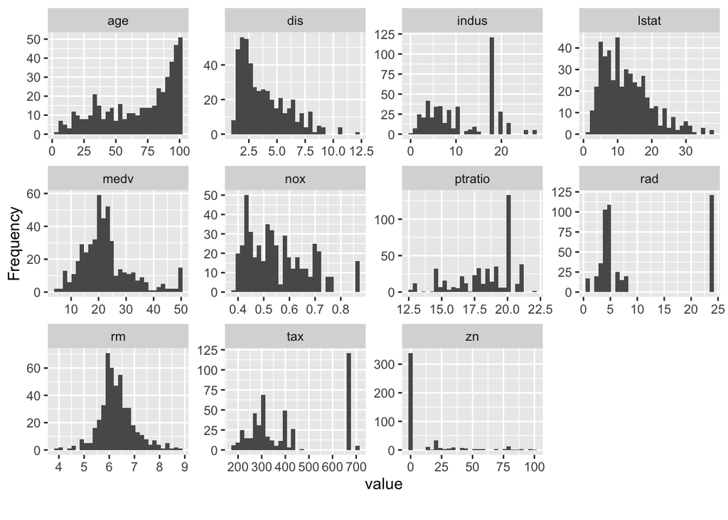

```
## [1] NA
```

Several predictors seem highly skewed and thereby, good candidates for transformation.

### Unique values and Modes

The variables indus, ptratio, rad, tax, and zn all have pronounced modes. Lets take a closer look at the proportion of distinct values to see how to treat these variables

```
## [1] "Indus unique values: "
```

```
## [1] 73
```

```
## [1] "Ptratio unique values: "
```

```
## [1] 46
```

```
## [1] "Rad unique values: "
```

```
## [1] 9
```

```
## [1] "Tax unique values: "
```

```
## [1] 63
```

```
## [1] "Zn unique values: "
```

```
## [1] 26
```

Rad in particular appears to only have 9 unique values. The description of this variable mentions it is an index, so it may be preferable to consider it a categorical variable in the regression.

```
## [1] "Indus most common values: "
```

```
##
##  18.1 19.58  8.14   6.2 21.89  3.97  8.56   9.9 10.59  5.86
##   121    28    19    16    14    12    11    11    10     9
```

```
## [1] "Ptratio most common values: "
```

```
##
## 20.2 14.7   21 17.8 19.2 16.6 17.4 18.6 18.4 19.1
##  128   32   23   22   17   16   16   16   14   14
```

```
## [1] "Rad most common values: "
```

```
##
##   24    5    4    3    6    2    8    1    7 <NA>
##  121  109  103   36   25   20   20   17   15
```

```
## [1] "Tax most common values: "
```

```
##
## 666 307 403 437 304 264 398 384 277 224
## 121  35  28  14  13  12  12  11  10   9
```

```
## [1] "Zn most common values: "
```

```
##
##    0   20   80 12.5   22   25   40   30   45   21
##  339   21   13   10    9    8    7    6    6    4
```

For 3 of the 5 variables, the mode is represented 121 times. Next, lets see if these variables coincide

```
## [1] 121
```

```
## [1] "Proportion of cluster above median crime rate: "
```

```
##   mean(target)
## 1            1
```

```
## [1] 26
```

```
## [1] 53
```

Counting the affected rows confirms that these modes have 100% overlap. This likely represents a cluster of values. And crucially, all 121 of these neighborhoods have above-median crime rates. This cluster represents 26% of all observations and over half of the high crime neighborhoods.

```
##
##   3   4   5   6   7   8  24
##   1  44  43   2   2  16 121
```

Finally, here’s a table looking at each index value for the rad variable. Of the 229 high crime neighborhoods, they are clearly not distributed evenly between the different index levels. For index values of 1 and 2, there are no high crime neighborhoods. It also doesn’t appear that there’s an increasing or descreasing pattern.

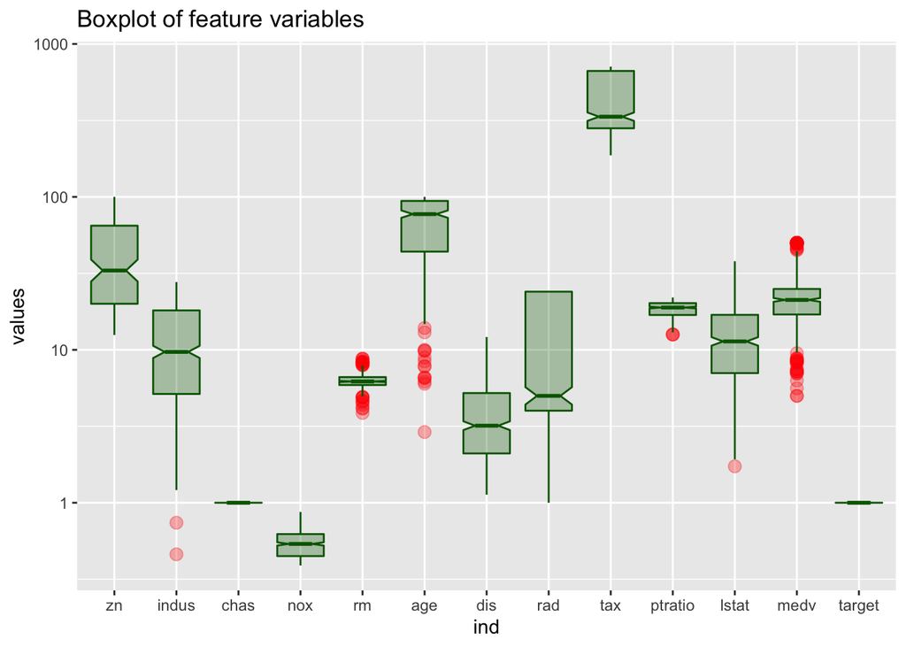

The above notched boxplots of feature variables confirms the skewness shown in corresponsding histograms. The notch displays the confidence interval around the median.

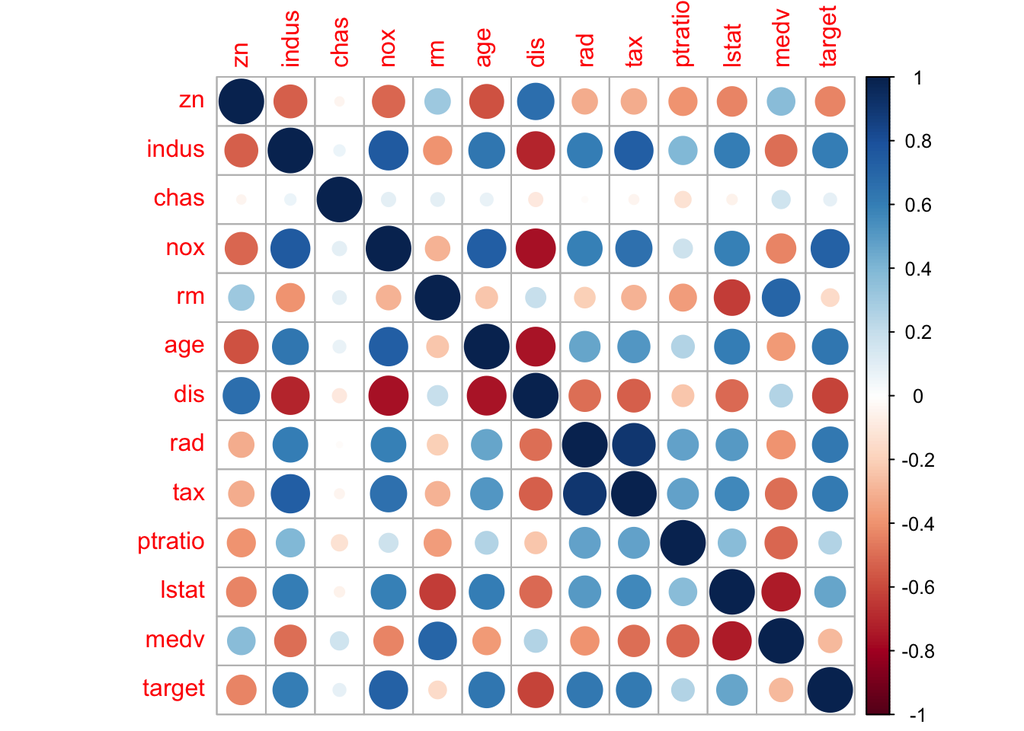

Our target variable, crime rate > median, has several strong correlations with predictors. These include NO concentrations, age of dwellings, accessibility to highways, and property tax rate. It is negatively correlated with distance to metro employment centers. There are also some variables that are strongly correlated with other predictors, including indus, nox, age, and dis. In particular,access to highways and property tax rate appear strongly correlated.

### Outliers

There appears to be a single outlier in our initial model, observation #338.

```
##     zn indus chas   nox    rm  age   dis rad tax ptratio lstat medv target
## 338 20  6.96    0 0.464 5.856 42.1 4.429   3 223    18.6    13 21.1      1
```

Looking back to our look at the rad variable, this appears to be the single high crime area with a rad value of 3.

# Data Preparation

Without any transformations, it appears NO concentrations are a strong predictor of crime. Nearby highways are also correlated.

## Zero Inflation

From a glance at the histogram for predictor ‘zn’, it seems like the number 0 occurs more frequently than any other values.

```
##       zn   n
## 1    0.0 339
## 2   12.5  10
## 3   17.5   1
## 4   18.0   1
## 5   20.0  21
## 6   21.0   4
## 7   22.0   9
## 8   25.0   8
## 9   28.0   3
## 10  30.0   6
## 11  33.0   3
## 12  34.0   3
## 13  35.0   3
## 14  40.0   7
## 15  45.0   6
## 16  52.5   3
## 17  55.0   3
## 18  60.0   4
## 19  70.0   3
## 20  75.0   3
## 21  80.0  13
## 22  82.5   2
## 23  85.0   2
## 24  90.0   4
## 25  95.0   4
## 26 100.0   1
```

```
##   zn   n
## 1  0 339
## 2  1 127
```

## Log Transformation

The predictors rad and dis are also highly skewed (ignoring chas since this is a categorical variable). Thus we will log transform these variables

```
## [1] NA
```

## Converting Categorical Variables to Factors

# Build Models

## Model 1

```
##
## Call:
## glm(formula = target ~ ., family = "binomial", data = crime_training)
##
## Deviance Residuals:
##     Min       1Q   Median       3Q      Max
## -1.8619  -0.1720  -0.0093   0.0025   3.6279
##
## Coefficients:
##               Estimate Std. Error z value Pr(>|z|)
## (Intercept) -41.811736   6.692341  -6.248 4.17e-10 ***
## zn           -1.883902   0.825331  -2.283 0.022454 *
## indus        -0.075087   0.048241  -1.556 0.119595
## chas          0.813853   0.766599   1.062 0.288399
## nox          51.109139   8.015632   6.376 1.82e-10 ***
## rm           -0.506323   0.732752  -0.691 0.489574
## age           0.034743   0.013882   2.503 0.012322 *
## dis           0.813769   0.232525   3.500 0.000466 ***
## rad           0.658720   0.161822   4.071 4.69e-05 ***
## tax          -0.006092   0.002937  -2.074 0.038073 *
## ptratio       0.349801   0.133116   2.628 0.008594 **
## lstat         0.066503   0.055534   1.198 0.231105
## medv          0.181696   0.068831   2.640 0.008297 **
## ---
## Signif. codes:  0 '***' 0.001 '**' 0.01 '*' 0.05 '.' 0.1 ' ' 1
##
## (Dispersion parameter for binomial family taken to be 1)
##
##     Null deviance: 645.88  on 465  degrees of freedom
## Residual deviance: 191.12  on 453  degrees of freedom
## AIC: 217.12
##
## Number of Fisher Scoring iterations: 9
```

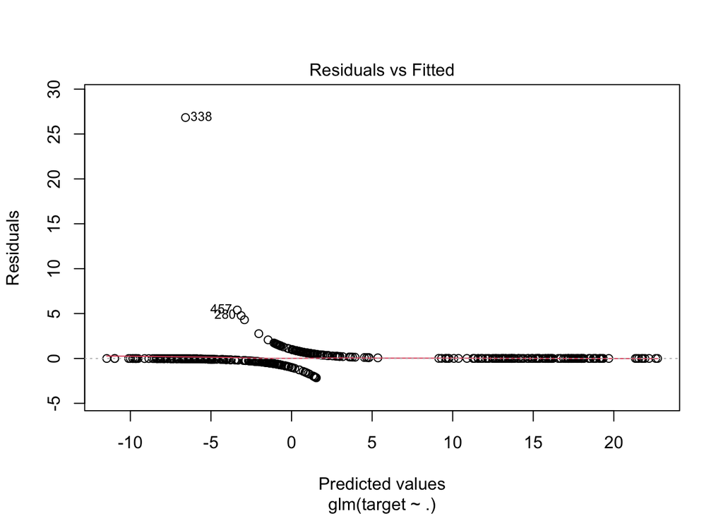

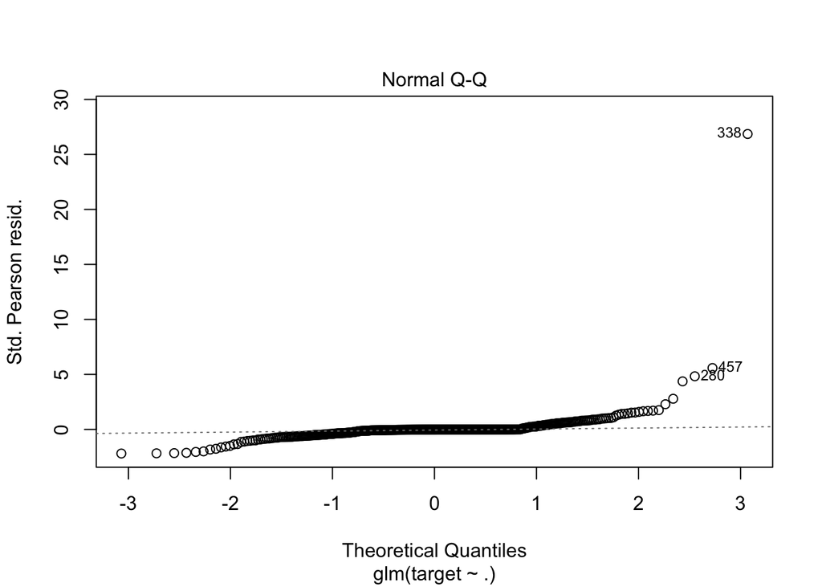

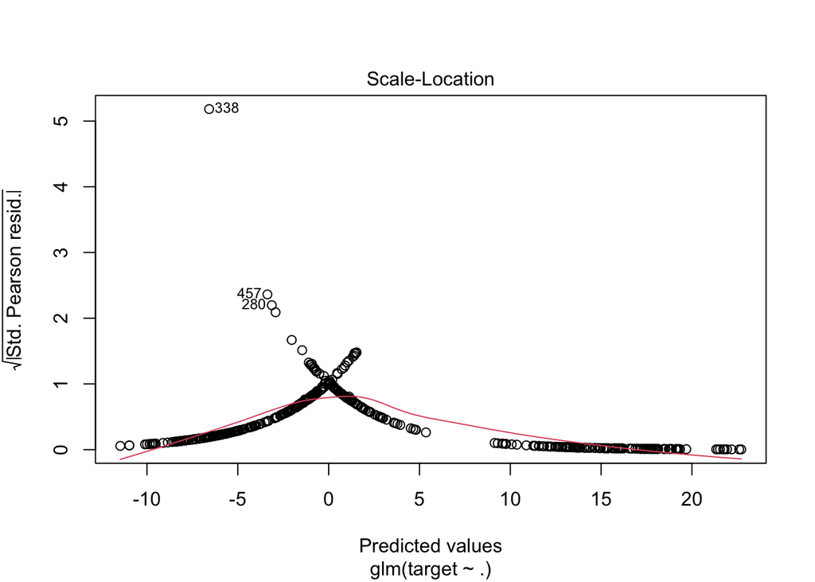

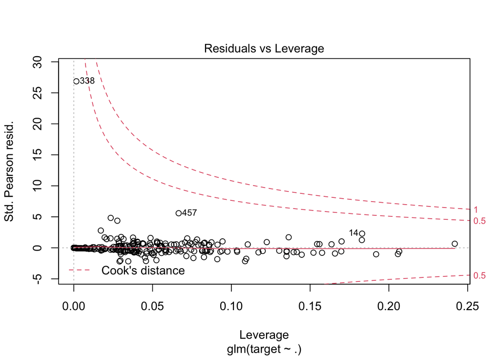

## Model 2

```
##
## Call:
## glm(formula = target ~ ., family = "binomial", data = crime_training_transf)
##
## Deviance Residuals:
##     Min       1Q   Median       3Q      Max
## -1.8363  -0.1216  -0.0024   0.0503   3.6314
##
## Coefficients:
##               Estimate Std. Error z value Pr(>|z|)
## (Intercept) -52.686872   7.820029  -6.737 1.61e-11 ***
## zn           -1.583651   0.764714  -2.071 0.038368 *
## indus        -0.019280   0.050833  -0.379 0.704476
## chas1         0.661458   0.759545   0.871 0.383830
## nox          51.874699   7.929493   6.542 6.07e-11 ***
## rm           -0.587980   0.760391  -0.773 0.439368
## age           0.039381   0.014402   2.734 0.006250 **
## dis           4.785211   1.283323   3.729 0.000192 ***
## rad           4.381985   0.955496   4.586 4.52e-06 ***
## tax          -0.006720   0.003251  -2.067 0.038740 *
## ptratio       0.414049   0.139458   2.969 0.002988 **
## lstat         0.056671   0.056210   1.008 0.313350
## medv          0.209401   0.073563   2.847 0.004420 **
## ---
## Signif. codes:  0 '***' 0.001 '**' 0.01 '*' 0.05 '.' 0.1 ' ' 1
##
## (Dispersion parameter for binomial family taken to be 1)
##
##     Null deviance: 645.88  on 465  degrees of freedom
## Residual deviance: 185.83  on 453  degrees of freedom
## AIC: 211.83
##
## Number of Fisher Scoring iterations: 8
```

## Model 3

```
##
## Call:
## glm(formula = target ~ rm * (tax + medv) + nox + indus + +rm +
##     medv + tax + as.factor(rad), family = "binomial", data = crime_training)
##
## Deviance Residuals:
##      Min        1Q    Median        3Q       Max
## -2.92126  -0.07629   0.00000   0.00000   2.90006
##
## Coefficients:
##                    Estimate Std. Error z value Pr(>|z|)
## (Intercept)       5.035e+01  8.852e+03   0.006 0.995462
## rm               -1.800e+01  4.762e+00  -3.781 0.000156 ***
## tax              -2.598e-01  7.320e-02  -3.549 0.000387 ***
## medv             -8.950e-01  4.670e-01  -1.916 0.055324 .
## nox               7.428e+01  1.275e+01   5.826 5.67e-09 ***
## indus            -1.532e-01  1.147e-01  -1.336 0.181440
## as.factor(rad)2  -9.355e-01  1.206e+04   0.000 0.999938
## as.factor(rad)3   2.169e+01  8.852e+03   0.002 0.998045
## as.factor(rad)4   2.411e+01  8.852e+03   0.003 0.997827
## as.factor(rad)5   2.105e+01  8.852e+03   0.002 0.998102
## as.factor(rad)6   1.904e+01  8.852e+03   0.002 0.998284
## as.factor(rad)7   2.714e+01  8.852e+03   0.003 0.997554
## as.factor(rad)8   2.710e+01  8.852e+03   0.003 0.997557
## as.factor(rad)24  6.484e+01  9.036e+03   0.007 0.994274
## rm:tax            4.132e-02  1.198e-02   3.447 0.000566 ***
## rm:medv           1.530e-01  7.091e-02   2.158 0.030947 *
## ---
## Signif. codes:  0 '***' 0.001 '**' 0.01 '*' 0.05 '.' 0.1 ' ' 1
##
## (Dispersion parameter for binomial family taken to be 1)
##
##     Null deviance: 645.88  on 465  degrees of freedom
## Residual deviance: 103.23  on 450  degrees of freedom
## AIC: 135.23
##
## Number of Fisher Scoring iterations: 21
```

## Model 4

In this model we transformed the variables **rad** and **dis** using log transformations and used backwards elimination to remove variables that are not predictive one at a time. As we removed variables the AIC value decreased which indicates a better goodness of fit.

```
##
## Call:
## glm(formula = target ~ zn + nox + age + dis + rad + tax + ptratio +
##     medv, family = "binomial", data = crime_training_sw_transf)
##
## Deviance Residuals:
##     Min       1Q   Median       3Q      Max
## -1.9221  -0.1519  -0.0030   0.0640   3.6054
##
## Coefficients:
##               Estimate Std. Error z value Pr(>|z|)
## (Intercept) -50.278505   7.450580  -6.748 1.50e-11 ***
## zn           -1.562858   0.698460  -2.238 0.025249 *
## nox          48.733194   7.190858   6.777 1.23e-11 ***
## age           0.039453   0.011494   3.432 0.000598 ***
## dis           4.368571   1.211356   3.606 0.000311 ***
## rad           4.382260   0.820225   5.343 9.15e-08 ***
## tax          -0.007458   0.002867  -2.601 0.009289 **
## ptratio       0.348239   0.121341   2.870 0.004106 **
## medv          0.132246   0.038195   3.462 0.000535 ***
## ---
## Signif. codes:  0 '***' 0.001 '**' 0.01 '*' 0.05 '.' 0.1 ' ' 1
##
## (Dispersion parameter for binomial family taken to be 1)
##
##     Null deviance: 645.88  on 465  degrees of freedom
## Residual deviance: 189.87  on 457  degrees of freedom
## AIC: 207.87
##
## Number of Fisher Scoring iterations: 8
```

# Select Models

## Model 1

This model was created using all parameters.

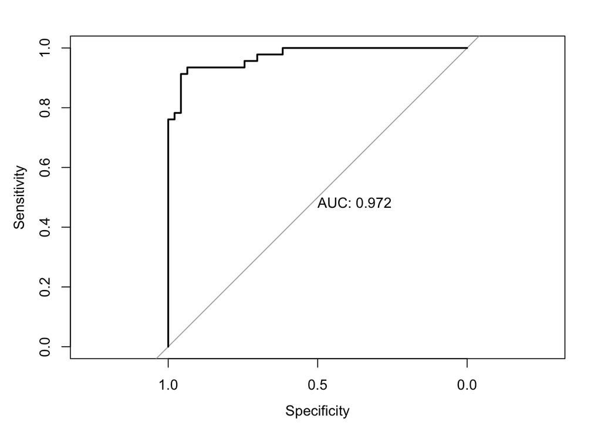

```
## Confusion Matrix and Statistics
##
##           Reference
## Prediction  0  1
##          0 45  3
##          1  1 44
##
##                Accuracy : 0.957
##                  95% CI : (0.8935, 0.9882)
##     No Information Rate : 0.5054
##     P-Value [Acc > NIR] : <2e-16
##
##                   Kappa : 0.914
##
##  Mcnemar's Test P-Value : 0.6171
##
##             Sensitivity : 0.9783
##             Specificity : 0.9362
##          Pos Pred Value : 0.9375
##          Neg Pred Value : 0.9778
##              Prevalence : 0.4946
##          Detection Rate : 0.4839
##    Detection Prevalence : 0.5161
##       Balanced Accuracy : 0.9572
##
##        'Positive' Class : 0
##
```

```
##
## Call:
## roc.default(response = y_test, predictor = predictions)
##
## Data: predictions in 47 controls (y_test 0) < 46 cases (y_test 1).
## Area under the curve: 0.9722
```

## Model 2

This model uses all parameters with log transformations on **rad** and **dis**

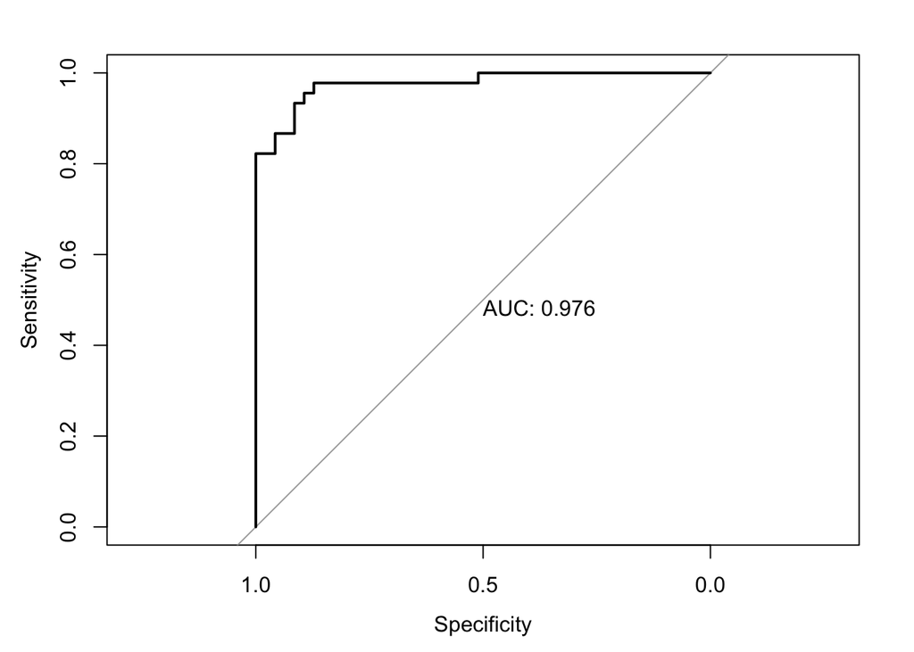

```
## Confusion Matrix and Statistics
##
##           Reference
## Prediction  0  1
##          0 45  3
##          1  2 42
##
##                Accuracy : 0.9457
##                  95% CI : (0.8777, 0.9821)
##     No Information Rate : 0.5109
##     P-Value [Acc > NIR] : <2e-16
##
##                   Kappa : 0.8912
##
##  Mcnemar's Test P-Value : 1
##
##             Sensitivity : 0.9574
##             Specificity : 0.9333
##          Pos Pred Value : 0.9375
##          Neg Pred Value : 0.9545
##              Prevalence : 0.5109
##          Detection Rate : 0.4891
##    Detection Prevalence : 0.5217
##       Balanced Accuracy : 0.9454
##
##        'Positive' Class : 0
##
```

```
##
## Call:
## roc.default(response = y_test, predictor = predictions)
##
## Data: predictions in 47 controls (y_test 0) < 45 cases (y_test 1).
## Area under the curve: 0.9764
```

## Model 3

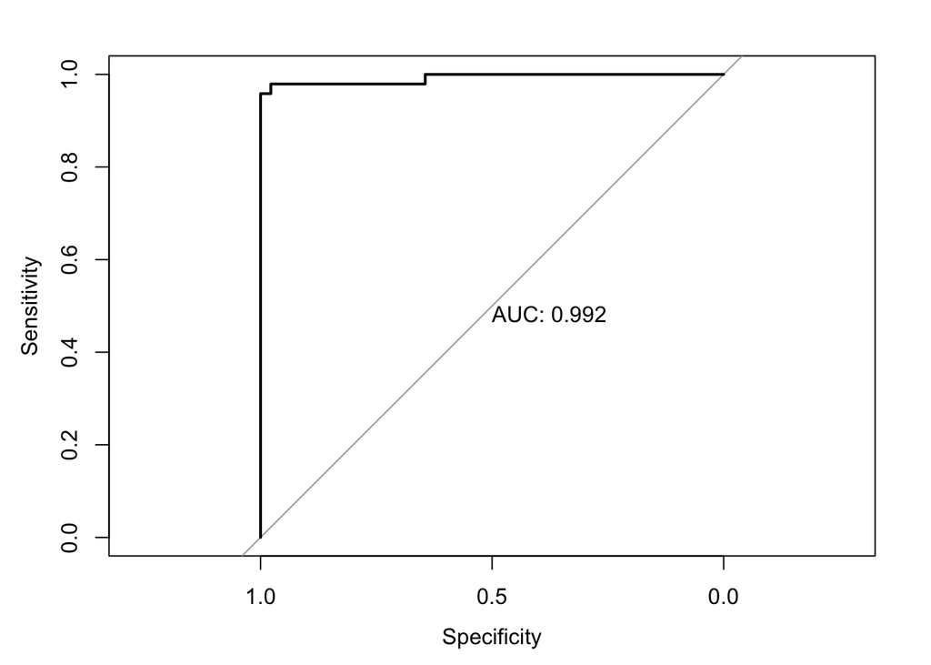

```
## Confusion Matrix and Statistics
##
##           Reference
## Prediction  0  1
##          0 48  2
##          1  0 43
##
##                Accuracy : 0.9785
##                  95% CI : (0.9245, 0.9974)
##     No Information Rate : 0.5161
##     P-Value [Acc > NIR] : <2e-16
##
##                   Kappa : 0.9569
##
##  Mcnemar's Test P-Value : 0.4795
##
##             Sensitivity : 1.0000
##             Specificity : 0.9556
##          Pos Pred Value : 0.9600
##          Neg Pred Value : 1.0000
##              Prevalence : 0.5161
##          Detection Rate : 0.5161
##    Detection Prevalence : 0.5376
##       Balanced Accuracy : 0.9778
##
##        'Positive' Class : 0
##
```

```
##
## Call:
## roc.default(response = y_test, predictor = predictions)
##
## Data: predictions in 45 controls (y_test 0) < 48 cases (y_test 1).
## Area under the curve: 0.9921
```

## Model 4

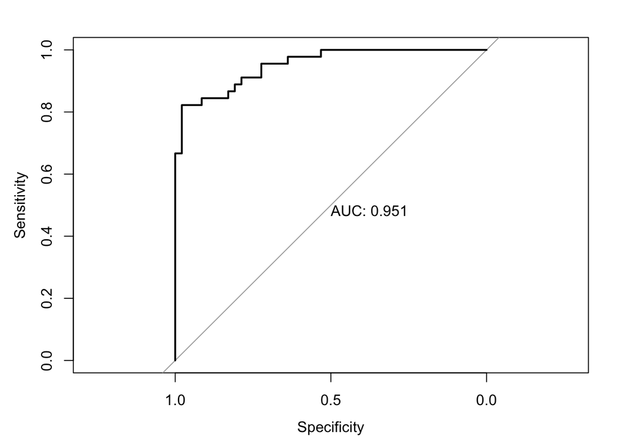

```
## Confusion Matrix and Statistics
##
##           Reference
## Prediction  0  1
##          0 43  4
##          1  4 41
##
##                Accuracy : 0.913
##                  95% CI : (0.8358, 0.9617)
##     No Information Rate : 0.5109
##     P-Value [Acc > NIR] : <2e-16
##
##                   Kappa : 0.826
##
##  Mcnemar's Test P-Value : 1
##
##             Sensitivity : 0.9149
##             Specificity : 0.9111
##          Pos Pred Value : 0.9149
##          Neg Pred Value : 0.9111
##              Prevalence : 0.5109
##          Detection Rate : 0.4674
##    Detection Prevalence : 0.5109
##       Balanced Accuracy : 0.9130
##
##        'Positive' Class : 0
##
```

```
##
## Call:
## roc.default(response = y_test, predictor = predictions)
##
## Data: predictions in 47 controls (y_test 0) < 45 cases (y_test 1).
## Area under the curve: 0.9513
```

## Conclusion

|  | Model1 | Model2 | Model3 | Model4 |
| --- | --- | --- | --- | --- |
| Description | All variables | Some log transformations | Fewer variables, new created variable | Backwards elmination, log transformations |
| AUC | 0.972247918593895 | 0.976359338061466 | 0.99212962962963 | 0.951300236406619 |
| accuracy | 0.957215541165587 | 0.945390070921986 | 0.977777777777778 | 0.913002364066194 |
| classification error rate | 0.0427844588344126 | 0.0546099290780142 | 0.0222222222222221 | 0.0869976359338062 |
| precision | 0.9375 | 0.9375 | 0.96 | 0.914893617021277 |
| sensitivity | 0.978260869565217 | 0.957446808510638 | 1 | 0.914893617021277 |
| specificty | 0.936170212765957 | 0.933333333333333 | 0.955555555555556 | 0.911111111111111 |
| F1 Score | 0.957446808510638 | 0.947368421052632 | 0.979591836734694 | 0.914893617021277 |

While all 4 models are great at predicting on our test data, Model 3 performs the best. The AUC value for Model 3 is the highest. The sensitivity, specificity, accuracy and error rate are the highest in Model 3 as well.

Our final model shows the biggest predictors of whether a town has a crime rate above the median is the avg number of rooms in a house, the nitrogen oxide concentrations, and index of accessibility to radial highways. Here is the final model:

$$\begin{eqnarray} target = 50.35025 - 18.00372rm - 0.25978tax -0.89499medv + 74.28452nox -0.15323indus - 0.93553rad2 + 21.68964rad3 + 24.10738rad4 + 21.0538rad5 +19.04056rad6 +27.13905rad7 + 27.10154rad8 + 64.83889rad24 + 0.04132rm:tax + 0.15300rm:medv \end{eqnarray}$$

## Predicting on the Evaluation Dataset

We will use our final model on the evaluation dataset to predict whether or not, the crime rate is above the median crime rate in a neighborhood. The assigned threshold for the median is 0.5.

```
##  1  2  3  4  5  6  7  8  9 10 11 12 13 14 15 16 17 18 19 20 21 22 23 24 25 26
##  0  1  1  1  0  0  0  0  0  0  0  0  1  1  1  0  1  1  0  0  0  0  1  0  0  0
## 27 28 29 30 31 32 33 34 35 36 37 38 39 40
##  0  1  1  1  1  1  1  1  1  1  1  1  0  0
## Levels: 0 1
```

# Code Appendix

The code chunks below shows the R code called above throughout the analysis. They are being reproduced in the appendix for review and feedback.

```r
# Libraries
library(dplyr)
library(GGally)
library(ggplot2)
library(readr)
library(reshape2)
library(purrr)
library(tidyr)
library(corrplot)
library(MASS)
library(caret)
library(e1071)
library(ROCR)
library(DataExplorer)
library(pROC)
library(kableExtra)
```

```r
set.seed(2012)

crime_training <- read.csv('https://raw.githubusercontent.com/hillt5/DATA_621/master/HW3/crime-training-data_modified.csv')
crime_eval <- read.csv('https://raw.githubusercontent.com/hillt5/DATA_621/master/HW3/crime-evaluation-data_modified.csv')
```

```r
head(crime_training)
dim(crime_training)
```

```r
summary(crime_training)
```

```r
plot_histogram(crime_training)
skewness(crime_training,na.rm=FALSE)
```

```r
print('Indus unique values: ')
length(unique(crime_training$indus))


print('Ptratio unique values: ')
length(unique(crime_training$ptratio))


print('Rad unique values: ')
length(unique(crime_training$rad))

print('Tax unique values: ')
length(unique(crime_training$tax))


print('Zn unique values: ')
length(unique(crime_training$zn))
```

```r
print('Indus most common values: ')
sort(table(crime_training$indus), decreasing = TRUE)[1:10]

print('Ptratio most common values: ')
sort(table(crime_training$ptratio), decreasing = TRUE)[1:10]


print('Rad most common values: ')
sort(table(crime_training$rad), decreasing = TRUE)[1:10]

print('Tax most common values: ')
sort(table(crime_training$tax), decreasing = TRUE)[1:10]


print('Zn most common values: ')
sort(table(crime_training$zn), decreasing = TRUE)[1:10]
```

```r
crime_training %>% filter(indus == 18.1) %>% filter(ptratio == 20.2) %>% filter(tax == 666) %>% nrow()



print('Proportion of cluster above median crime rate: ')

crime_training %>% filter(indus == 18.1) %>% filter(ptratio == 20.2) %>% filter(tax == 666) %>% summarize(mean(target))

100*round(121/nrow(crime_training),2)
100*round(121/nrow(crime_training[crime_training$target == 1,]),2)
```

```r
table((crime_training$rad[crime_training$target ==1]))
```

```r
ggplot(stack(crime_training), aes(x = ind, y = values)) +
  geom_boxplot(color = "darkgreen", fill = "darkgreen", alpha = 0.3, notch = TRUE,
               notchwidth = 0.5, outlier.colour = "red", outlier.fill = "red",
               outlier.size = 3) +
  labs(title = "Boxplot of feature variables") +
  scale_y_log10()
```

```r
corrplot(cor(crime_training))
```

```r
crime_training[338,]
```

```r
count(crime_training,zn)
```

```r
crime_training$zn <- ifelse(crime_training$zn == 0, 0, 1) # 0 indicates that the neighborhood does not have residential land zoned for large lots and 1 indicates that it does
count(crime_training,zn)
```

```r
crime_training_transf <- crime_training
crime_training_transf$rad <- log(crime_training_transf$rad+1)
crime_training_transf$dis <- log(crime_training_transf$dis+1)
skewness(crime_training_transf,na.rm=FALSE)
```

```r
crime_training_transf$chas = as.factor(crime_training_transf$chas)
crime_training_transf$target = as.factor(crime_training_transf$target)
```

```r
# Model 1
crime_glm <- glm(crime_training, family = 'binomial', formula = target ~.)
summary(crime_glm)
```

```r
# plot model 1
plot(crime_glm)
```

```r
# transformed model
lm_transform <- glm(crime_training_transf, family = 'binomial', formula = target ~.)
summary(lm_transform)
```

```r
crime_glm2 <- glm(crime_training, formula = target~rm*(tax + medv) + nox + indus + +rm  + medv + tax + as.factor(rad), family = 'binomial')

summary(crime_glm2)
```

```r
crime_training_sw_transf <- crime_training
crime_training_sw_transf$rad <- log(crime_training_sw_transf$rad+1)
crime_training_sw_transf$dis <- log(crime_training_sw_transf$dis+1)

crime_training_sw_transf$chas   = as.factor(crime_training_sw_transf$chas)
crime_training_sw_transf$target = as.factor(crime_training_sw_transf$target)


crime_glm4 <- glm(crime_training_sw_transf, formula = target ~ ., family = 'binomial')
#summary(crime_glm4)
crime_glm4 <- update(crime_glm4,target~. - indus) #remove indus
#summary(crime_glm4)
crime_glm4 <- update(crime_glm4,target~. - lstat) #remove lstat
#summary(crime_glm4)
crime_glm4 <- update(crime_glm4,target~. - chas) #remove chas
#summary(crime_glm4)
crime_glm4 <- update(crime_glm4,target~. - rm) #remove rm
summary(crime_glm4)
```

```r
get_cv_performance <- function(data_frame, model, split = 0.8) {  ### input is dataframe for partitioning, model as generated by 'glm' function, by default 5-fold cross-validation
  n <- ncol(data_frame) #number of columns in original dataframe
  train_control <- trainControl(method="repeatedcv", number=10, repeats=3)
  trainIndex <- createDataPartition(data_frame[,n], p=split, list=FALSE)
  data_train <- data_frame[trainIndex,]
  data_test <- data_frame[-trainIndex,]


  x_test <- data_test[,1:n] #explanatory variables
  y_test <- data_test[,n]  #response variable

  predictions <- predict(model, x_test, type = 'response')


  return(confusionMatrix(data = (as.factor(as.numeric(predictions>0.5))), reference = as.factor(y_test)))


  return(plot(roc(y_test, predictions),print.auc=TRUE))

}
```

```r
get_roc <- function(data_frame, model, split = 0.8) {  ### input is dataframe for partitioning, model as generated by 'glm' function
  n <- ncol(data_frame) #number of columns in original dataframe
  train_control <- trainControl(method="repeatedcv", number=10, repeats=3)
  trainIndex <- createDataPartition(data_frame[,n], p=split, list=FALSE)
  data_train <- data_frame[trainIndex,]
  data_test <- data_frame[-trainIndex,]


  x_test <- data_test[,1:n] #explanatory variables
  y_test <- data_test[,n]  #response variable

  predictions <- predict(model, x_test, type = 'response')

  return(plot(roc(y_test, predictions),print.auc=TRUE))

}
```

```r
model1_cv <- get_cv_performance(crime_training, crime_glm)
model1_roc <- get_roc(crime_training, crime_glm)
model1_cv
model1_roc
```

```r
model2_cv <- get_cv_performance(crime_training_transf, lm_transform)
model2_roc <- get_roc(crime_training_transf, lm_transform)
model2_cv
model2_roc
```

```r
model3_cv <- get_cv_performance(crime_training, crime_glm2)
model3_roc <- get_roc(crime_training, crime_glm2)
model3_cv
model3_roc
```

```r
model4_cv <- get_cv_performance(crime_training_sw_transf, crime_glm4)
model4_roc <- get_roc(crime_training_sw_transf, crime_glm4)
model4_cv
model4_roc
```

```r
Model_1 <- c("All variables",model1_roc$auc,model1_cv$byClass["Balanced Accuracy"],1-model1_cv$byClass["Balanced Accuracy"],model1_cv$byClass["Precision"],model1_cv$byClass["Sensitivity"],model1_cv$byClass["Specificity"],model1_cv$byClass["F1"])

Model_2 <- c("Some log transformations",model2_roc$auc,model2_cv$byClass["Balanced Accuracy"],1-model2_cv$byClass["Balanced Accuracy"],model2_cv$byClass["Precision"],model2_cv$byClass["Sensitivity"],model2_cv$byClass["Specificity"],model2_cv$byClass["F1"])

Model_3 <- c("Fewer variables, new created variable",model3_roc$auc,model3_cv$byClass["Balanced Accuracy"],1-model3_cv$byClass["Balanced Accuracy"],model3_cv$byClass["Precision"],model3_cv$byClass["Sensitivity"],model3_cv$byClass["Specificity"],model3_cv$byClass["F1"])

Model_4 <- c("Backwards elmination, log transformations",model4_roc$auc,model4_cv$byClass["Balanced Accuracy"],1-model4_cv$byClass["Balanced Accuracy"],model4_cv$byClass["Precision"],model4_cv$byClass["Sensitivity"],model4_cv$byClass["Specificity"],model4_cv$byClass["F1"])

results <- cbind(Model_1,Model_2,Model_3,Model_4)

colnames(results) <- c('Model1', 'Model2', 'Model3','Model4')
rownames(results) <- c('Description','AUC','accuracy','classification error rate','precision','sensitivity','specificty','F1 Score')

results %>%
  kable() %>%
  kable_styling()
```

```r
prediction <- predict(crime_glm2, newdata = crime_eval)
prediction[prediction >= 0.5] <- 1
prediction[prediction < 0.5] <- 0
prediction = as.factor(prediction)
prediction
```